# Project: Communicating Data Findings

## Part I - Prosper Loan Exploration

## by Dorothy Nguyen

- Introduction
- Preliminary Wrangling
- Univariate Exploration
- Bivariate Exploration
- Multivariate Exploration

## Introduction

> This project is conducted as a part of Udacity Data Analyst Nanodegree. The purpose of this project is to perform exploratory data analysis, then create a presentation with explanatory charts that conveys findings and insights from the data set provided.

> The studied data set contains 113,937 loans with 81 variables on each loan provided by Prosper Marketplace, California-based pioneering company in the peer-to-peer lending industry in the U.S. Since its establishment in 2005, Prosper has helped more than 1.3 million customers get access to over $21 billion in affordable loans ([source](https://www.prosper.com))

> Each loan includes loan amount, borrower rate (or interest rate), loan status, borrower income, and many others. This [data dictionary](https://docs.google.com/spreadsheets/d/1gDyi_L4UvIrLTEC6Wri5nbaMmkGmLQBk-Yx3z0XDEtI/edit#gid=0) contains specific details on every single dataset's variable.

> In this analysis, I am focusing on the main research question of what factors affect the borrowing interest rate?

## Preliminary Wrangling

> In this section, I load in the dataset, inspect its properties and conduct data wrangling for further exploration

```python
# import all necessary packages
import numpy as np
import pandas as pd
import matplotlib.pyplot as plt
import seaborn as sb
# set plots to be embedded inline in Jupyter Notebook
%matplotlib inline
```

```python
# load the Prosper Loan dataset into a pandas dataframe
df=pd.read_csv('prosperLoanData.csv')
print(df.shape)
# Set display option to show all the columns
pd.set_option('display.max_columns', None)
# Display the first 5 rows
df.head()
```

```
(113937, 81)
```

|  | ListingKey | ListingNumber | ListingCreationDate | CreditGrade | Term | LoanStatus | ClosedDate | BorrowerAPR | BorrowerRate | LenderYield | EstimatedEffectiveYield | EstimatedLoss | EstimatedReturn | ProsperRating (numeric) | ProsperRating (Alpha) | ProsperScore | ListingCategory (numeric) | BorrowerState | Occupation | EmploymentStatus | EmploymentStatusDuration | IsBorrowerHomeowner | CurrentlyInGroup | GroupKey | DateCreditPulled | CreditScoreRangeLower | CreditScoreRangeUpper | FirstRecordedCreditLine | CurrentCreditLines | … |
| --- | --- | --- | --- | --- | --- | --- | --- | --- | --- | --- | --- | --- | --- | --- | --- | --- | --- | --- | --- | --- | --- | --- | --- | --- | --- | --- | --- | --- | --- | --- |
| 0 | 1021339766868145413AB3B | 193129 | 2007-08-26 19:09:29.263000000 | C | 36 | Completed | 2009-08-14 00:00:00 | 0.16516 | 0.1580 | 0.1380 | NaN | NaN | NaN | NaN | NaN | NaN | 0 | CO | Other | Self-employed | 2.0 | True | True | NaN | 2007-08-26 18:41:46.780000000 | 640.0 | 659.0 | 2001-10-11 00:00:00 | 5.0 | … |
| 1 | 10273602499503308B223C1 | 1209647 | 2014-02-27 08:28:07.900000000 | NaN | 36 | Current | NaN | 0.12016 | 0.0920 | 0.0820 | 0.07960 | 0.0249 | 0.05470 | 6.0 | A | 7.0 | 2 | CO | Professional | Employed | 44.0 | False | False | NaN | 2014-02-27 08:28:14 | 680.0 | 699.0 | 1996-03-18 00:00:00 | 14.0 | … |
| 2 | 0EE9337825851032864889A | 81716 | 2007-01-05 15:00:47.090000000 | HR | 36 | Completed | 2009-12-17 00:00:00 | 0.28269 | 0.2750 | 0.2400 | NaN | NaN | NaN | NaN | NaN | NaN | 0 | GA | Other | Not available | NaN | False | True | 783C3371218786870A73D20 | 2007-01-02 14:09:10.060000000 | 480.0 | 499.0 | 2002-07-27 00:00:00 | NaN | … |
| 3 | 0EF5356002482715299901A | 658116 | 2012-10-22 11:02:35.010000000 | NaN | 36 | Current | NaN | 0.12528 | 0.0974 | 0.0874 | 0.08490 | 0.0249 | 0.06000 | 6.0 | A | 9.0 | 16 | GA | Skilled Labor | Employed | 113.0 | True | False | NaN | 2012-10-22 11:02:32 | 800.0 | 819.0 | 1983-02-28 00:00:00 | 5.0 | … |
| 4 | 0F023589499656230C5E3E2 | 909464 | 2013-09-14 18:38:39.097000000 | NaN | 36 | Current | NaN | 0.24614 | 0.2085 | 0.1985 | 0.18316 | 0.0925 | 0.09066 | 3.0 | D | 4.0 | 2 | MN | Executive | Employed | 44.0 | True | False | NaN | 2013-09-14 18:38:44 | 680.0 | 699.0 | 2004-02-20 00:00:00 | 19.0 | … |

```python
# Overview of data shape, variable data types and their missing values
df.info()
```

```
<class 'pandas.core.frame.DataFrame'>
RangeIndex: 113937 entries, 0 to 113936
Data columns (total 81 columns):
ListingKey                             113937 non-null object
ListingNumber                          113937 non-null int64
ListingCreationDate                    113937 non-null object
CreditGrade                            28953 non-null object
Term                                   113937 non-null int64
LoanStatus                             113937 non-null object
ClosedDate                             55089 non-null object
BorrowerAPR                            113912 non-null float64
BorrowerRate                           113937 non-null float64
LenderYield                            113937 non-null float64
EstimatedEffectiveYield                84853 non-null float64
EstimatedLoss                          84853 non-null float64
EstimatedReturn                        84853 non-null float64
ProsperRating (numeric)                84853 non-null float64
ProsperRating (Alpha)                  84853 non-null object
ProsperScore                           84853 non-null float64
ListingCategory (numeric)              113937 non-null int64
BorrowerState                          108422 non-null object
Occupation                             110349 non-null object
EmploymentStatus                       111682 non-null object
EmploymentStatusDuration               106312 non-null float64
IsBorrowerHomeowner                    113937 non-null bool
CurrentlyInGroup                       113937 non-null bool
GroupKey                               13341 non-null object
DateCreditPulled                       113937 non-null object
CreditScoreRangeLower                  113346 non-null float64
CreditScoreRangeUpper                  113346 non-null float64
FirstRecordedCreditLine                113240 non-null object
CurrentCreditLines                     106333 non-null float64
OpenCreditLines                        106333 non-null float64
TotalCreditLinespast7years             113240 non-null float64
OpenRevolvingAccounts                  113937 non-null int64
OpenRevolvingMonthlyPayment            113937 non-null float64
InquiriesLast6Months                   113240 non-null float64
TotalInquiries                         112778 non-null float64
CurrentDelinquencies                   113240 non-null float64
AmountDelinquent                       106315 non-null float64
```

[output cut: 31 more lines]

```
LP_CustomerPayments                    113937 non-null float64
LP_CustomerPrincipalPayments           113937 non-null float64
LP_InterestandFees                     113937 non-null float64
LP_ServiceFees                         113937 non-null float64
LP_CollectionFees                      113937 non-null float64
LP_GrossPrincipalLoss                  113937 non-null float64
LP_NetPrincipalLoss                    113937 non-null float64
LP_NonPrincipalRecoverypayments        113937 non-null float64
PercentFunded                          113937 non-null float64
Recommendations                        113937 non-null int64
InvestmentFromFriendsCount             113937 non-null int64
InvestmentFromFriendsAmount            113937 non-null float64
Investors                              113937 non-null int64
dtypes: bool(3), float64(50), int64(11), object(17)
memory usage: 68.1+ MB
```

> Out of 81 columns, I am selecting about 15 columns that are relevant to our loan exploration project. These columns are related to loan interest rates, the amount of loan, loan status and the characteristics of the borrowers such as their incomes and credit scores.

```python
# Create a list of columns corresponding to this analysis
analyzed_vars=['ListingKey','Term', 'LoanStatus', 'BorrowerAPR','BorrowerRate', 'ProsperRating (Alpha)', 'ProsperScore',
               'ListingCategory (numeric)', 'EmploymentStatus','IncomeRange', 'StatedMonthlyIncome','LoanOriginalAmount',
               'LoanOriginationDate','MonthlyLoanPayment']
# Create the new dataframe used for analyzing
df_reduced_vars = df.loc[:,analyzed_vars]
```

> Some variables require the transformation on their data types. Specifically, I should convert IncomeRange and ProsperRating (Alpha) to be ordinal types since they have intrinsic ranking order in their natures.

> To be more specific, Prosper Rating is Prosper's estimation of borrower's estimated loss rate which is determined based on two scores: (1) the credit score, obtained from an official credit reporting agency, and (2) the Prosper Score, figured in-house based on the Prosper population. Prosper ratings are labeled AA, A, B, C, D, E, and HR, with AA being related to the lowest-risk customers.

```python
# Convert ordinal variables into ordered categorical types
ordinal_var_dict = {'IncomeRange':['$0','$1-24,999','$25,000-49,999','$50,000-74,999','$75,000-99,999','$100,000+'],
                    'ProsperRating (Alpha)': ['HR','E','D','C', 'B', 'A', 'AA']}

for var in ordinal_var_dict:
    ordered_var = pd.api.types.CategoricalDtype(ordered = True,
                                                categories = ordinal_var_dict[var])
    df_reduced_vars[var] = df_reduced_vars[var].astype(ordered_var)
```

```python
# Set the nominal variables to be category data type
df_reduced_vars['ListingCategory (numeric)'] = df_reduced_vars['ListingCategory (numeric)'].astype('category')

df_reduced_vars['EmploymentStatus'] = df_reduced_vars['EmploymentStatus'].astype('category')
```

```python
# Set the datetime variable to be datetime data type
df_reduced_vars['LoanOriginationDate']=pd.to_datetime(df_reduced_vars['LoanOriginationDate'])
```

> Next, I am making two adjustments to LoanStatus and ListingCategory fields.

```python
# Take a look at unique values of LoanStatus and their occurrences
df_reduced_vars['LoanStatus'].value_counts()
```

```
Current                   56576
Completed                 38074
Chargedoff                11992
Defaulted                  5018
Past Due (1-15 days)        806
Past Due (31-60 days)       363
Past Due (61-90 days)       313
Past Due (91-120 days)      304
Past Due (16-30 days)       265
FinalPaymentInProgress      205
Past Due (>120 days)         16
Cancelled                     5
Name: LoanStatus, dtype: int64
```

> The first change is the grouping of all of the past due categories into one category Past Due. Past Due, Chargedoff, and Defaulted (in that order) are the stages of defaulting on a loan. Otherwise, the loan is sucessfully Completed.

```python
# Make a copy for new Loan Status column named LoanStatus_grouped
df_reduced_vars['LoanStatus_grouped']=df_reduced_vars['LoanStatus']
# Change values containing all of the past due categories to 'Past Due'
past_due=df_reduced_vars['LoanStatus_grouped'].str.contains("Past Due")
df_reduced_vars.loc[past_due, 'LoanStatus_grouped'] = 'Past Due'
# Set Loan Status to be category data type
df_reduced_vars['LoanStatus_grouped'] = df_reduced_vars['LoanStatus_grouped'].astype('category')
```

```python
# Check if the change on Loan status attribute is made
df_reduced_vars['LoanStatus_grouped'].value_counts()
```

```
Current                   56576
Completed                 38074
Chargedoff                11992
Defaulted                  5018
Past Due                   2067
FinalPaymentInProgress      205
Cancelled                     5
Name: LoanStatus_grouped, dtype: int64
```

> The second change I would like to make is to map ListingCategory (numeric) on their qualitative Listing categories in accordance with data dictionary definition: 0 - Not Available, 1 - Debt Consolidation, 2 - Home Improvement, 3 - Business, 4 - Personal Loan, 5 - Student Use, 6 - Auto, 7- Other, 8 - Baby&Adoption, 9 - Boat, 10 - Cosmetic Procedure, 11 - Engagement Ring, 12 - Green Loans, 13 - Household Expenses, 14 - Large Purchases, 15 - Medical/Dental, 16 - Motorcycle, 17 - RV, 18 - Taxes, 19 - Vacation, 20 - Wedding Loans.

```python
# Create a dictionary to hold the key and value of each ListingCategory respectively
listing_category_dict={0:'Not Available',1:'Debt Consolidation',2:'Home Improvement',3:'Business',4:'Personal Loan',5:'Student Use',
                      6:'Auto',7:'Other',8:'Baby&Adoption',9:'Boat',10:'Cosmetic Procedure',11:'Engagement Ring',
                      12:'Green Loans',13:'Household Expenses',14:'Large Purchases',15:'Medical/Dental',16:'Motorcycle',
                       17:'RV',18:'Taxes',19:'Vacation',20:'Wedding Loans'}

# Build a function to map a numeric listing category on its corresponding alpha value
def listing_category(x):
    if x in list(listing_category_dict.keys()):
        return (listing_category_dict[x])
    else:
        return ('No found')

# Apply the function above to the ListingCategory (alpha) column
df_reduced_vars['ListingCategory'] = df_reduced_vars['ListingCategory (numeric)'].apply(listing_category)

# Check if the new ListingCategory is updated and all the variables in the dataset are set to proper data types for analysis
df_reduced_vars.info()
```

```
<class 'pandas.core.frame.DataFrame'>
RangeIndex: 113937 entries, 0 to 113936
Data columns (total 16 columns):
ListingKey                   113937 non-null object
Term                         113937 non-null int64
LoanStatus                   113937 non-null object
BorrowerAPR                  113912 non-null float64
BorrowerRate                 113937 non-null float64
ProsperRating (Alpha)        84853 non-null category
ProsperScore                 84853 non-null float64
ListingCategory (numeric)    113937 non-null category
EmploymentStatus             111682 non-null category
IncomeRange                  105390 non-null category
StatedMonthlyIncome          113937 non-null float64
LoanOriginalAmount           113937 non-null int64
LoanOriginationDate          113937 non-null datetime64[ns]
MonthlyLoanPayment           113937 non-null float64
LoanStatus_grouped           113937 non-null category
ListingCategory              113937 non-null category
dtypes: category(6), datetime64[ns](1), float64(5), int64(2), object(2)
memory usage: 9.3+ MB
```

```python
# Overview of descriptive statistics for numeric variables
print(df_reduced_vars.describe())
```

```
                Term    BorrowerAPR   BorrowerRate  ProsperScore  \
count  113937.000000  113912.000000  113937.000000  84853.000000
mean       40.830248       0.218828       0.192764      5.950067
std        10.436212       0.080364       0.074818      2.376501
min        12.000000       0.006530       0.000000      1.000000
25%        36.000000       0.156290       0.134000      4.000000
50%        36.000000       0.209760       0.184000      6.000000
75%        36.000000       0.283810       0.250000      8.000000
max        60.000000       0.512290       0.497500     11.000000

       StatedMonthlyIncome  LoanOriginalAmount  MonthlyLoanPayment
count         1.139370e+05        113937.00000       113937.000000
mean          5.608026e+03          8337.01385          272.475783
std           7.478497e+03          6245.80058          192.697812
min           0.000000e+00          1000.00000            0.000000
25%           3.200333e+03          4000.00000          131.620000
50%           4.666667e+03          6500.00000          217.740000
75%           6.825000e+03         12000.00000          371.580000
max           1.750003e+06         35000.00000         2251.510000
```

```python
# Check for duplication in the dataset
df_reduced_vars.duplicated().sum()
```

```
0
```

### Overvew of dataset for further exploration

#### What is the structure of dataset?

> The dataset contains 113937 rows and 16 columns, including both quantitative and qualitative variables. In term of qualitative variables, there are both ordinal and nominal categorical variables with the following stages for ordinal ones (lowest) ——> (highest):

> > Income range: 0, 1-24,999, 25,000-49,999, 50,000-74,999, 75,000-99,999, 100,000+

> > ProsperRating: HR, E, D, C, B, A, AA

#### What are the main features of interest in this dataset?

> I would like to discover what are the major features for predicting the borrower interest rate of loan in the dataset.

#### What features in the dataset will help support the investigation into the features of interest?

> I presume that customer risk score and income will have the most significant influences on each loan interest rate. In Prosper Marketplace system, a custom risk score is built using its historical data. The score ranges from 1-11, with 11 being the best, or lowest risk score. Interchangeably, Prosper rating scale varies from HR to AA, with AA being the lowest risk credit rating customers. Bearing that idea in mind, the relationships I expect from my discovery is that the higher credit rating and income the borrowers get, the better outcomes they will acquire for their loans in terms of interest rate.

> Additionally, I'm also interested in the effects of, for example, Listing Category and Employment Status on loan borrowing rate outcomes.

## Univariate Exploration

> In this section, I start by having a look at the distributions of the main variable of interest: BorrowerAPR.

> BorrowerAPR is the Borrower's Annual Percentage Rate (APR) for the loan which is generally equal or higher than the BorrowerRate since it includes not only interest rate but also all the service fees applicable.

```python
# Overview of BorrowerAPR distribution
df_reduced_vars['BorrowerAPR'].describe()
```

```
count    113912.000000
mean          0.218828
std           0.080364
min           0.006530
25%           0.156290
50%           0.209760
75%           0.283810
max           0.512290
Name: BorrowerAPR, dtype: float64
```

```python
# Eliminate null values of BorrowerAPR from exploration
df_APR_notnull=df_reduced_vars.loc[~df_reduced_vars['BorrowerAPR'].isnull()]
df_APR_notnull.shape
```

```
(113912, 16)
```

```python
# Add functions for facilitating plot drawing to avoid code repetition on the exploration

def x_y_t(xaxis,yaxis,title):
    '''
   Function that return any chart title and its X-axis, Y-axis
    '''
    plt.xlabel(xaxis,size=10)
    plt.ylabel(yaxis,size=10)
    plt.title(title,size=13);

def plot_hist_charts(binsize,col):
    '''
   Function that return histogram for continuous variable with its correspondingly proper binsize
    '''
    bins = np.arange(col.min(), col.max()+binsize,binsize)
    plt.figure(figsize=[10, 5])
    plt.hist(col,bins=bins)

def plot_log_charts(log_binsize,col):
    '''
   Function that return log transformation histogram for continuous variable with its correspondingly proper binsize
    '''
    # Condition to handle the case when a variable takes zero values and can't get logarithmic transformation
    # but need adding value 1 to all the values in that variable to make log transformation legitimate.
    if col.min()==0:
        col_new=col+1
        bins = 10 ** np.arange(np.log10(col_new.min()), np.log10(col_new.max())+log_binsize, log_binsize)
    else:
        bins = 10 ** np.arange(np.log10(col.min()), np.log10(col.max())+log_binsize, log_binsize)
    plt.figure(figsize=[10, 5])
    plt.hist(col,bins=bins)
    plt.xscale('log')
```

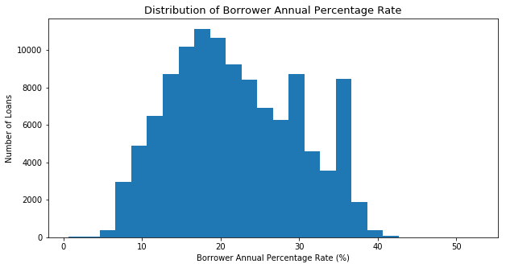

```python
import warnings
warnings.filterwarnings('ignore')

# Multiple BorrowerAPR by 100 to get values in term of percentage on the full dataset
df_reduced_vars['BorrowerAPR_percent']=df_reduced_vars['BorrowerAPR'].mul(100)
# Multiple BorrowerAPR by 100 to get values in term of percentage on the smaller subset without null values of Borrower APR
df_APR_notnull['BorrowerAPR_percent']=df_APR_notnull['BorrowerAPR'].mul(100)
# Plotting histogram for BorrowerAPR
plot_hist_charts(2,df_APR_notnull['BorrowerAPR_percent'])
x_y_t('Borrower Annual Percentage Rate (%)','Number of Loans','Distribution of Borrower Annual Percentage Rate');
```

> The chart depicts that the Borrower APR is approximately normally distrubuted with the peak around 20 percent. The first peak trails off till the next peaks at 30 and 35 percent.

> The second distribution I would like to inspect is the Original Amount of Loan.

```python
df_reduced_vars['LoanOriginalAmount'].describe()
```

```
count    113937.00000
mean       8337.01385
std        6245.80058
min        1000.00000
25%        4000.00000
50%        6500.00000
75%       12000.00000
max       35000.00000
Name: LoanOriginalAmount, dtype: float64
```

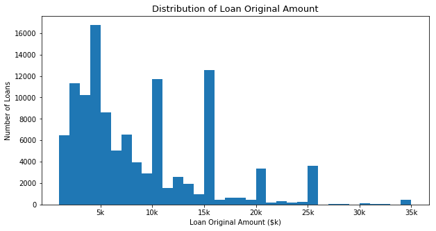

```python
# Plotting histogram for LoanOriginalAmount
plot_hist_charts(1000,df_reduced_vars['LoanOriginalAmount'])
plt.xticks([5e3,1e4,15e3,20e3,25e3,30e3,35e3],['5k','10k','15k','20k','25k','30k','35k'])
x_y_t('Loan Original Amount ($k)','Number of Loans','Distribution of Loan Original Amount');
```

> Loan amount exhibits a strong right-skewed pattern. I conduct the log transformation on LoanOriginalAmount to get a clearer distribion of this variable.

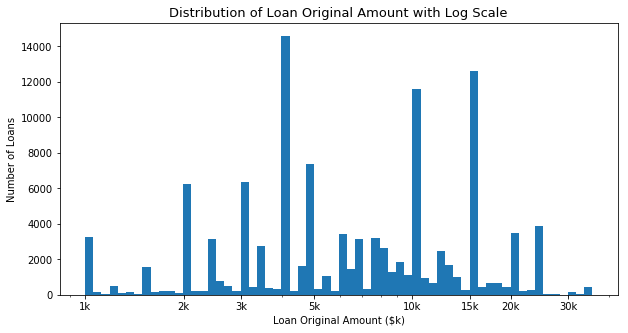

```python
# Plotting histogram for LoanOriginalAmount with log transformation
plot_log_charts(0.025,df_reduced_vars['LoanOriginalAmount'])
plt.xticks([1e3,2e3,3e3,5e3,1e4,15e3,20e3,3e4],['1k','2k','3k','5k','10k','15k','20k','30k'])
x_y_t('Loan Original Amount ($k)','Number of Loans','Distribution of Loan Original Amount with Log Scale');
```

> As shown by chart, the highest frequency of original loan amount is between 3K and 5K, frequency quickly trails off until the next spikes at 10k and 15k

> To continue, I apply subplot chart to inspect the patterns of Loan Status along with two other nominal variables, Employment Status and Listing Category.

```python
def chart_order(var):
    '''
    Function to return the order of value_counts() for any column
    '''
    order=df_reduced_vars[var].value_counts().index
    return order
```

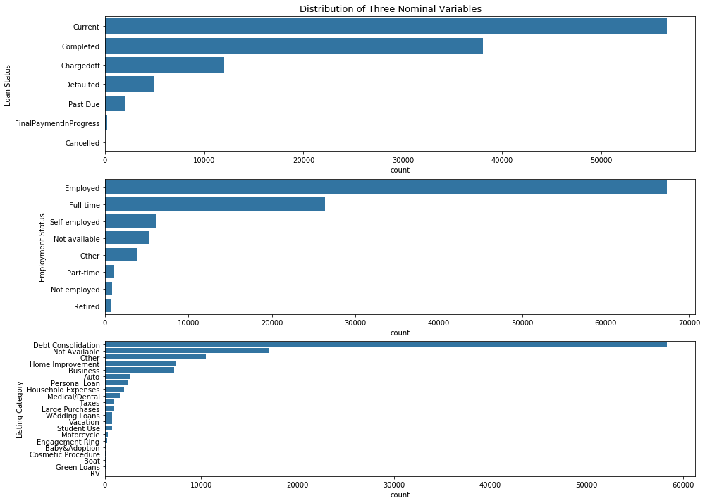

```python
# let's plot the distributions of three nominal variables.
fig, ax = plt.subplots(nrows=3, figsize = [15,12])
default_color=sb.color_palette()[0]
fig.suptitle('Distribution of Three Nominal Variables',y = 0.9, x = 0.5,size=13)
ax1=sb.countplot(data = df_reduced_vars, y= 'LoanStatus_grouped', color = default_color, ax = ax[0],order=chart_order('LoanStatus_grouped'))
ax2=sb.countplot(data = df_reduced_vars, y= 'EmploymentStatus', color = default_color, ax = ax[1],order=chart_order('EmploymentStatus'))
ax3=sb.countplot(data = df_reduced_vars, y= 'ListingCategory', color = default_color, ax = ax[2],order=chart_order('ListingCategory'))
ax1.set_ylabel('Loan Status',size=10)
ax2.set_ylabel('Employment Status',size=10)
ax3.set_ylabel('Listing Category',size=10);
```

> In regards to loan status, approximately 57 thousands, equivalent to half amount of loan transactions are currently on-going which we don't know yet either it would be defaulted or not. About 38 thousands, which consists of one third of loan agreements in Prosper marketplace platform were completed sucessfully. Interestingly, the number of loan contracts that fell into three different stages of defaulting on the loans which are in the order of Past Due, Chargedoff, and Defaulted were roughly half the amount of sucessful deals.

> In term of employment status, employed customers constitutes 60% of Prosper borrowers while only less than 1% of Prosper customers are unemployed.

> When it comes to listing category, half of borrowers listed the purpose of their loan applications is to consolidate a debt which is a type of loan used to combine all the existing debts into one pot at a lower interest rate. The second and third biggest amount of loan applications fall into 'Not Available' and 'Other' categories with 15% and 9% respectively. The next two most popular listing categories are home improvement with 6.5% and business with 6.3% .

> The other two qualitative variables I would like to investigate in this analysis are Prosper score, Prosper Rating (Alpha) and IncomeRange.

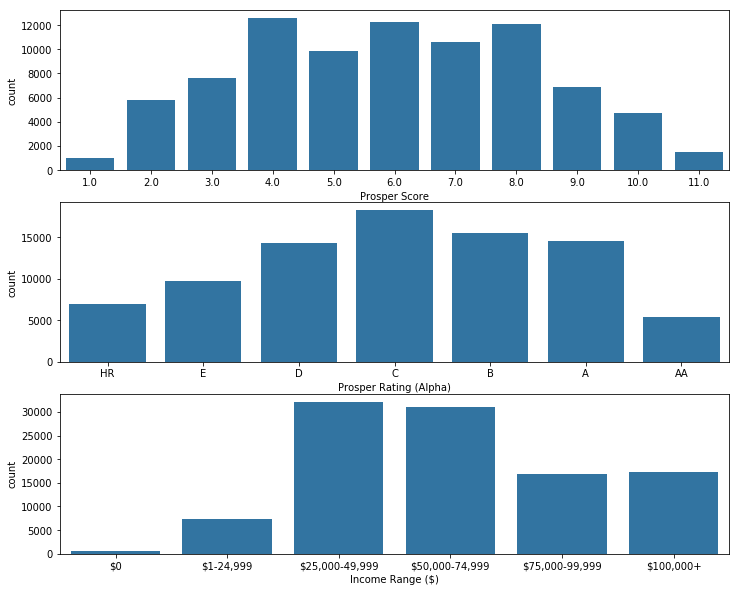

```python
# Create plot of Prosper Score, Prosper Rating (Alpha) and IncomeRange's distributions
fig, ax = plt.subplots(nrows=3, figsize = [12,10])

ax1=sb.countplot(data = df_reduced_vars, x= 'ProsperScore', color = default_color, ax = ax[0])
ax2=sb.countplot(data = df_reduced_vars, x= 'ProsperRating (Alpha)', color = default_color, ax = ax[1])
ax3=sb.countplot(data = df_reduced_vars, x= 'IncomeRange', color = default_color, ax = ax[2])
ax1.set_xlabel('Prosper Score',size=10)
ax2.set_xlabel('Prosper Rating (Alpha)',size=10)
ax3.set_xlabel('Income Range ($)',size=10);
```

> From the charts, we can see that borrowers who are taking most of the loans from Prosper platform are of Prosper score of 4,6,8 and Prosper Rating C. Prosper score and Prosper Rating seem to similarly follow normal distributions. For the sake of simplicity, I choose to move forward with Prosper Rating (Alpha) as a measure of credit rating scale.

> The income ranges of the customers in the dataset is generally above average, with most of them in the 25k-50k or 50k-75k level.

> We will have a look at what kind of terms customers make payment for their loans?

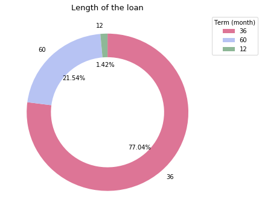

```python
# Draw a donut chart for the length of loan in term of months
plt.figure(figsize=[6, 6])
plt.pie(df_reduced_vars['Term'].value_counts(), labels=chart_order('Term'), colors = ['#DD7596','#B7C3F3','#8EB897'],
        startangle=90,counterclock=False,autopct='%1.2f%%',wedgeprops={'width':0.3})
plt.title('Length of the loan',size=13)
plt.legend(bbox_to_anchor=(1,1),title='Term (month)',loc="upper left");
```

> In regard to the length of the loan, there are three terms that customers can opt for their loan payments which can be either 1 year (12 month) or 3 years (36 months) or 5 years (60 months). The donut chart indicates that majority of customers which stood at 77% have the term of 3 years.

> I continue by inspecting the numeric features which are Stated Monthly Income and Monthly Loan Payment.

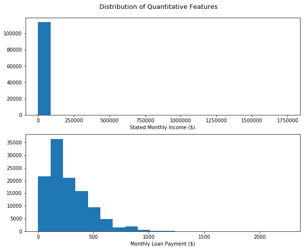

```python
# Plots to show the distributions of Stated Monthly Income and Monthly Loan Payment
fig, ax = plt.subplots(nrows=2, figsize = [10,8])
fig.suptitle('Distribution of Quantitative Features',y = 0.93, x = 0.5,size=13)
variables = ['StatedMonthlyIncome','MonthlyLoanPayment']
pd_data=df_reduced_vars.dropna(subset=variables).copy()
for i in range(len(variables)):
    var = variables[i]
    ax[i].hist(data = pd_data, x = var, bins = 20)
ax[0].set_xlabel('Stated Monthly Income ($)')
ax[1].set_xlabel('Monthly Loan Payment ($)');
```

> These histograms indicate that monthly incomes and monthly loan payments are right-skewed. Log transformation shall be applied to these variables for clearer picture of how they distribute.

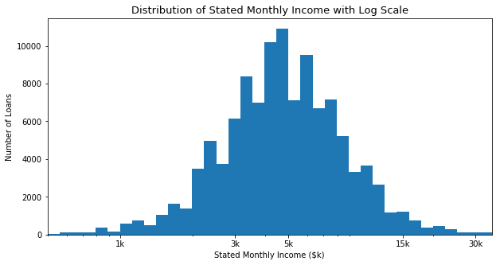

```python
# Plotting histogram for 'StatedMonthlyIncome' with log transformation
plot_log_charts(0.05,df_reduced_vars['StatedMonthlyIncome'])
plt.xticks([1e3,3e3,5e3,15e3,3e4],['1k','3k','5k','15k','30k'])
plt.xlim(500,35000)
x_y_t('Stated Monthly Income ($k)','Number of Loans','Distribution of Stated Monthly Income with Log Scale');
```

```python
df_reduced_vars['MonthlyLoanPayment'].describe()
```

```
count    113937.000000
mean        272.475783
std         192.697812
min           0.000000
25%         131.620000
50%         217.740000
75%         371.580000
max        2251.510000
Name: MonthlyLoanPayment, dtype: float64
```

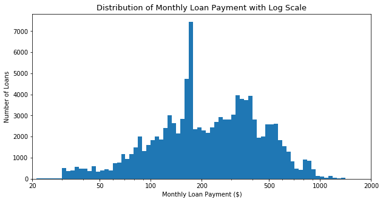

```python
# Plotting histogram for 'MonthlyLoanPayment' with log transformation
plot_log_charts(0.025,df_reduced_vars['MonthlyLoanPayment'])
plt.xticks([10,20, 50, 100, 200, 500, 1e3, 2e3], ['10', '20','50', '100', '200', '500', '1000', '2000'])
plt.xlim(20,2000)
x_y_t('Monthly Loan Payment ($)','Number of Loans','Distribution of Monthly Loan Payment with Log Scale');
```

> Under the transformation, the data on Monthly Income and Loan Payment look normally distributed, with one peak between 5k for Monthly Income before trailing off, and one peak be approximately close to 200 for Monthly Loan Payment.

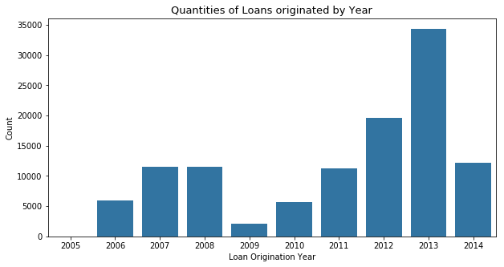

```python
# Distribution of loan origination by year
plt.figure(figsize=[10, 5])
sb.countplot(data=df_reduced_vars,x=df_reduced_vars['LoanOriginationDate'].dt.year,color=default_color)
x_y_t('Loan Origination Year','Count','Quantities of Loans originated by Year');
```

> The bar shows that there is a decrease in 2009 in amount of loans before it started increasing progressively and reached its peak in 2013. One of the reasons why loans dropped significantly in 2009 could be that on November 24, 2008, the U.S.Securities and Exchange Commission(SEC) stated the Prosper's violation of the Securities Act of 1933. As a result of these investigations, the SEC imposed a cease and desist order on Prosper which was valid until July 2009. After that period of time, Prosper obtained SEC registration for its loan and started relaunching their website for lending loans [source](https://en.wikipedia.org/wiki/Prosper_Marketplace).

### Summary of univariate exploratory analysis

#### How is the distribution of variable of interest. Are there any unusual points? Any transformations needed?

> The BorrowerAPR variable took a normal distribution with the peak around 20%. There is the tranformation of this Borrower APR into the form of percentage for the sake of analysis.

#### Are there any unusual distributions of the features? What kind of performance made on the data to tidy, adjust, or change the form of the data?

> Loan Original Amount distribution is right skewed so I performed log transformation to take a closer look at the data. Under the log transformation, the data looked multimodal with one peak between 3K and 5K, and then reaching a couple of other peaks at 10K and 15K.

> Loan status reveals that the rate of a loan being successfully completed doubles that of a loan falling into the defaulting status (either Past Due, Chargedoff or Defaulted).

> There are right-skewed distributions on monthly income and loan payment, hence log transform was conducted on them to get a better view of the hidden distribution in some areas.

> When it comes to employment status, listing category, and loan term, we experience a highly disproportionate proportion of customers falling into different categories. Specifically, major portion of Prosper customers are Employed and taking loans over the period of 36 months for consolidating their debts.

> Loan Origination Year experiences a decrease in 2009 in amount of loans before it started increasing progressively and reached its peak in 2013.

## Bivariate Exploration

> In order to choose the appropriate chart types to investigate pairwise correlations between variables in the data, I seperate variables into two groups which are numeric variables and categorical variables.

```python
# Distinguish two groups of variables
numeric_vars = ['Term','BorrowerAPR', 'BorrowerRate', 'ProsperScore','StatedMonthlyIncome','LoanOriginalAmount','MonthlyLoanPayment']
categoric_vars = ['LoanStatus_grouped', 'ProsperRating (Alpha)','EmploymentStatus','IncomeRange']
```

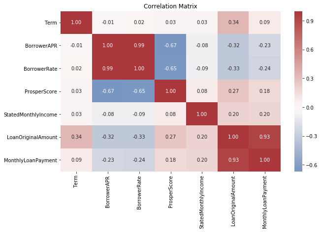

```python
# Correlation plot
plt.figure(figsize = [10, 6])
sb.heatmap(df_reduced_vars[numeric_vars].corr(), annot = True, fmt = '.2f',cmap = 'vlag', center = 0)
plt.title('Correlation Matrix');
```

```
df_reduced_vars.shape= (113937, 17)
pd_data2.shape= (1525, 17)
```

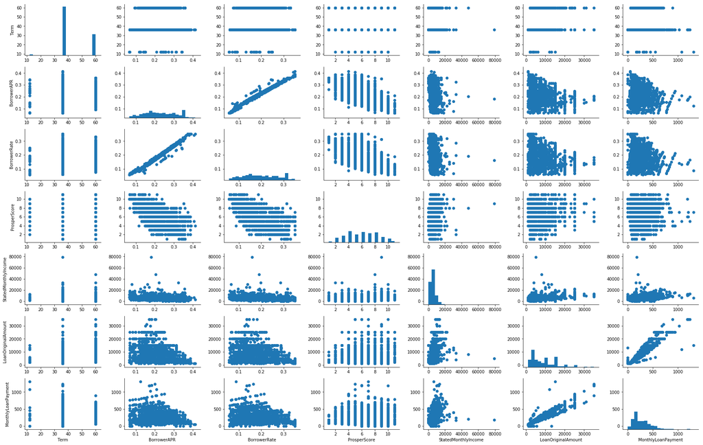

```python
# Plot matrix: sample 2000 loans so that plots are clearer and they render faster
print("df_reduced_vars.shape=",df_reduced_vars.shape)
loan_samp =df_reduced_vars.sample(n=2000, replace = False)
cols_dropna=numeric_vars
pd_data2=loan_samp.dropna(subset=cols_dropna).copy()
print("pd_data2.shape=",pd_data2.shape)

g = sb.PairGrid(data = pd_data2, vars = numeric_vars)
g = g.map_diag(plt.hist, bins = 20)
g.map_offdiag(plt.scatter)

# Set Plot Dimensions - figurelevel
g.fig.set_size_inches(24,15);
```

> BorrowerRate and Borrower APR are highly correlated since Borrower APR includes BorrowerRate and all service fees applicable.

> The second most positive significant relationship is between loan original amount and monthly loan payment. This makes sense in the mechanism that the higher loan amount customers borrow, the greater amount each month they expect to pay.

> As expected, the correlation coefficient between Borrower APR and Prosper score is strongly negative. Since Prosper score is a measure of customer credit risk, it's not surprising that the lower prosper score borrowers get, the more expensive interest rate they are supposed to obtain for their loans.

> Another seemingly interesting negative correlation is between borrower interest rate and original amount of loan. It appears that with the higher sum of original loan, Prosper customer has a tendency to receive a more favorable borrowing rate.

> Similar to monthly loan payment, term is also positively corrected with loan original amount. This is not much of suprise since customers are more likely to opt for the greater length of loan when they borrow a bigger sum of money. In that way, the amount they have to pay monthly will deliver a smaller effect on their monthly budget.

> Finally, we see positive correlations between stated monthly income with amount of original loan and monthly loan payment. These relationships could be explained in the way that customers with more stable monthly income can be approved with higher bulk of original loan and monthly loan payment.

> I continue by inspecting how Borrower APR and loan original amount correlate with the categorical variables.

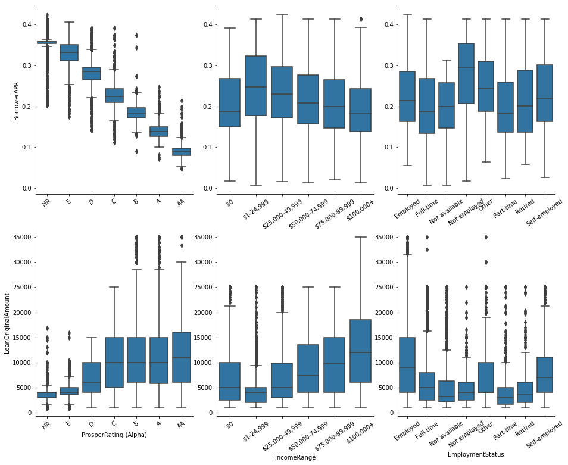

```python
def boxchart(x, y, **kwargs):
    """
    Function to create box plots with seaborn's PairGrid.
    """
    default_color = sb.color_palette()[0]
    sb.boxplot(x=x, y=y, color=default_color)

g = sb.PairGrid(data = df_reduced_vars, y_vars=['BorrowerAPR', 'LoanOriginalAmount'],
                x_vars = ['ProsperRating (Alpha)','IncomeRange','EmploymentStatus'],size=3,aspect=1.5)
g.map(boxchart)
g.fig.set_size_inches(13,11)
for ax in g.axes.flat:
    ax.set_xticklabels(ax.get_xticklabels(), rotation=35);
```

> Interestingly, among three categorical variables, Prosper rating score appears to have the strongest relationships with the two numeric variables but in two opposite directions, negative correlation with interest rate but positive relationship with Loan original amount. Similarly, the customers with the higher income ranges seem to get the cheaper borrowing rate, and also tend to be provided with bigger on loan amount. Except for customers with income range standing at zero, they appear to share an opposite trend.

> Employed customers have lower mean interest rate, smaller inner quartile range of Borrower APR and greater original loan amount than the group of unemployed customers.

> To continue, let's look at the correlations between Loan Status and two categorical features: Prosper rating and Income range.

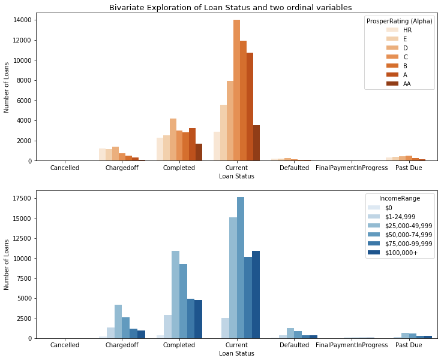

```python
# Plot Loan Status and two categorical features
fig, ax = plt.subplots(nrows=2, figsize = [12,10])
fig.suptitle('Bivariate Exploration of Loan Status and two ordinal variables',y = 0.9, x = 0.5,size=13)

# subplot 1: Loan status vs. Prosper rating
ax1=sb.countplot(data = df_reduced_vars, x = 'LoanStatus_grouped', hue = 'ProsperRating (Alpha)', palette = 'Oranges',ax=ax[0])

# subplot 2: Loan status vs. Income range
ax2=sb.countplot(data = df_reduced_vars, x = 'LoanStatus_grouped', hue = 'IncomeRange', palette = 'Blues',ax=ax[1])

# Set labels for two plots
ax1.set_xlabel('Loan Status',size=10)
ax2.set_xlabel('Loan Status',size=10)
ax1.set_ylabel('Number of Loans',size=10)
ax2.set_ylabel('Number of Loans',size=10);
```

> It looks like there appears to be greater proportion of safer credit rating and higher income range customers on the Current and Completed baskets of Loan Status compared to the group of defaulting (including Past Due, ChargedOff and Defaulted) customers.

> After some preliminary bivariate explorations, I move on by taking a closer look on some certain relationships. First, I want to see how BorrowerAPR and Loan Original Amount are correlated to one another on the full data set, and to plot Loan Original Amount on a log scale.

```python
# Compute the logarithm of Loan Original Amount to make multivariate plotting easier
def log_trans(x, inverse = False):
    """ Function to compute log and power operations """
    if not inverse:
        return np.log10(x)
    else:
        return np.power(10, x)

df_reduced_vars['log_loan_amount'] = df_reduced_vars['LoanOriginalAmount'].apply(log_trans)
```

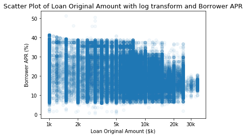

```python
# Create the scatter plot of BorrowerAPR and Loan Original Amount on the log transform with full data
plt.scatter(data = df_reduced_vars, x = 'log_loan_amount', y = 'BorrowerAPR_percent', alpha = 1/20)
plt.xticks(log_trans(np.array([1e3, 2e3, 5e3, 1e4, 2e4,3e4])),
               ['1k', '2k', '5k', '10k', '20k','30k'])
x_y_t('Loan Original Amount ($k)','Borrower APR (%)','Scatter Plot of Loan Original Amount with log transform and Borrower APR');
```

> This plot suggests a negative relationship between Borrower annual percentage rate and loan original amount, meaning bigger quantities of loan resulting in cheaper borrowing rates for customers.

> How about the relationship between categorical variable of Loan Status with Borrower APR and loan original amount?

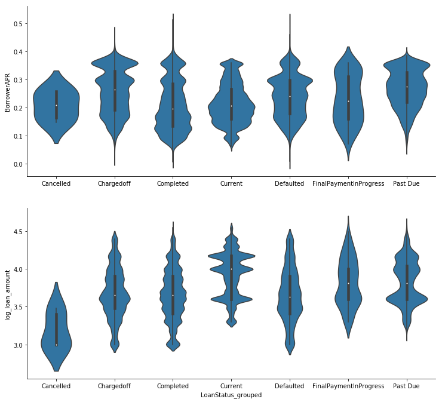

```python
def violinchart(x, y, **kwargs):
    """
    Function to create violin plots with seaborn's PairGrid.
    """
    default_color = sb.color_palette()[0]
    sb.violinplot(x=x, y=y, color=default_color)

# plot the categorical variable against Borrower APR and variable transform on Loan Original Amount with the full data set
g = sb.PairGrid(data = df_reduced_vars, y_vars=['BorrowerAPR', 'log_loan_amount'],
                x_vars = ['LoanStatus_grouped'],size=3,aspect=1.5)
g.map(violinchart)

# Set plot title and dimensions - figurelevel
g.fig.set_size_inches(12,10);
```

> The first violin plot reveals that the Completed loans appear to get lower rate on average than the loans belonging in the defaulting category (in the defaulting order of Past Due, Chargedoff and Defaulted).

> The second violin plot does not show that much of any clear relationship between original loan amount and loan status.

> Finally, we will inspect if there is any correlation between the numeric variable of interest and all the 21 listed categories among Prosper customers over the period of analysis.

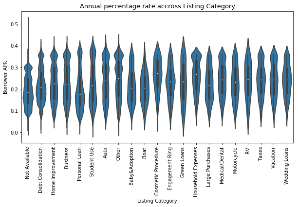

```python
# Create plot of Borrower APR and Listing Category
plt.figure(figsize=[10, 5])
sb.violinplot(data = df_reduced_vars, x = 'ListingCategory', y='BorrowerAPR',color=default_color)
plt.xticks(rotation=90)
x_y_t('Listing Category', 'Borrower APR','Annual percentage rate accross Listing Category');
```

> Out of 21 listing categories, Cosmestic Procedure and Household Expenses have experienced the most expensive loans on average. On the contrary, Personal Loan and Not available seem to get cheaper borrowing rates.

> Other than that, listing category does not seem to deliver any clear trend or relationship to the numeric variable of interest. Hence, I rather not conducting any further analyses with this categorical variable in the upcoming multivariate exploration section.

### Summary of bivariate exploration

#### Some of the main relationships I have observed in this part of the investigation. How do the features of interest vary with other features in the dataset?

> BorrowerRate and Borrower APR have a surprisingly high amount of correlation. The reason is because Borrower APR includes BorrowerRate and all yearly service fees applicable.

> A significant negative linear relationship is found between Borrower APR and Prosper score. This correlation appears to be in line with our expectation. Since customer credit score is a measure of customer credit risk, it's not surprising that the lower prosper score borrowers are assessed, the more expensive interest rate they are supposed to obtain for their loans.

> There appears also seemingly interesting negative correlation between borrower interest rate and original amount of loan. Prosper customers who got a bigger loan amount are associated with decreasing annual interest rate. One of the reasonably explanatory factor is the fact that customers approved bigger amount of loan are also associated with cheaper loans due to their trustworthy credit scores. This worths further investigating in the upcoming multivariate exploration section.

> Finally, bivariate exploration depicts that past due, chargedoff, and defaulted loans generally have higher interest rates. On the contrary, completed loans seem to be the ones that have the lowest interest rate.

#### Any interesting relationships between the other features observed?

> Monthly loan payment and term are positively corrected with loan original amount. This can be explained due to the fact that the bigger loan amount customers receive, the more considerable monthly loan amount and longer period of months they are supposed to pay back their loans.

## Multivariate Exploration

> In this section of exploration, I am creating plots of three or more variables to investigate the data set even further based on my work in the previous sections.

> First of all, I am inspecting how loan original amount and borrower APR have interacted across Prosper Rating.

```python
# Transpose describe dataframe of Loan Original Amount to make decision on the bin of new categorical variable 'LoanAmount'
df_reduced_vars['LoanOriginalAmount'].describe().to_frame().T
```

|  | count | mean | std | min | 25% | 50% | 75% | max |
| --- | --- | --- | --- | --- | --- | --- | --- | --- |
| LoanOriginalAmount | 113937.0 | 8337.01385 | 6245.80058 | 1000.0 | 4000.0 | 6500.0 | 12000.0 | 35000.0 |

```python
# use floor division (lowest integer value) to create categorical variable
df_reduced_vars['LoanAmount']=((df_reduced_vars['LoanOriginalAmount']//3000)*3000)
df_reduced_vars['LoanAmount'].value_counts().sort_index()
```

```
0        17815
3000     35622
6000     15490
9000     16180
12000     5479
15000    13690
18000     4433
21000      669
24000     3896
27000       50
30000      162
33000      451
Name: LoanAmount, dtype: int64
```

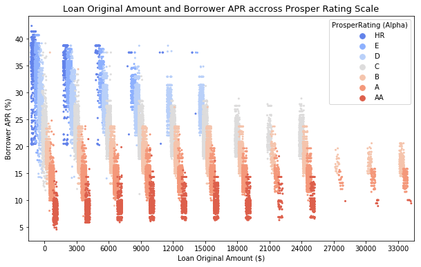

```python
# Create striplot of Loan Original Amount and Borrower APR accross Prosper Rating Scale
plt.figure(figsize = [10, 6])
ax=sb.stripplot(data=df_reduced_vars,x='LoanAmount',y = 'BorrowerAPR_percent' ,hue='ProsperRating (Alpha)',jitter=0.5,palette='coolwarm',dodge=True ,size=3)
x_y_t('Loan Original Amount ($)','Borrower APR (%)','Loan Original Amount and Borrower APR accross Prosper Rating Scale');
```

> Interestingly, the plot also depicts a hidden factor that drives the relationship between interest rate and loan amount in the previous exploration. In the earlier section, the scatter plots suggests that bigger loan amount seems to get cheaper interest rates. But with multivariate exploration, we can see clearly that prosper rating scale appears to be the factor that affects both borrower APR and original loan amount. The reason why bigger loan amount receives smaller interest rates is because the customers who can get more considerate amounts of loan are the ones having high credit ratings, which seems to lead to cheaper borrowing rates.

> Secondly, I am interested to see how loan original amount and borrowing rate are associated with monthly loan payment.

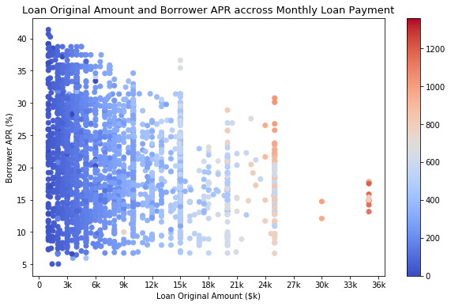

```python
# Create a random sample of 3000 loans from the full dataset to deal with overplotting issue
np.random.seed(2018)
sample_3000=np.random.choice(df_reduced_vars.shape[0],3000,replace=False)
subset_3000=df_reduced_vars.loc[sample_3000]
plt.figure(figsize = [10, 6])
plt.scatter(data = subset_3000, x = 'LoanOriginalAmount', y = 'BorrowerAPR_percent',c='MonthlyLoanPayment',cmap='coolwarm')
plt.xticks([0,3e3,6e3,9e3,12e3,15e3,18e3,21e3,24e3,27e3,30e3,33e3,36e3],
           ['0','3k', '6k', '9k','12k', '15k', '18k', '21k','24k', '27k', '30k', '33k','36k'])
plt.colorbar()
x_y_t('Loan Original Amount ($k)','Borrower APR (%)','Loan Original Amount and Borrower APR accross Monthly Loan Payment');
```

> The scatter plot depicts a significant postive correlation between loan original amount and monthly loan payment which is in line with the finding in the bivariate exploration above. High proportion of borrowers seem to take loans smaller than 10k,mostly between 3K and 5K and pay less than 200 monthly. At the point when the loan amount is greater than 15k, the monthly loan payment seems to be increasing to between 200 and 600. For loan amounts that varies between 20k and 30k, there are progressively increase in the monthly loan payment to between 600 and 1000. Lastly, there are few customers borrowing more than 30k and paying monthly more than 1k.

> Next, we are looking at Loan Original Amount and Monthly Loan Payment accross Term

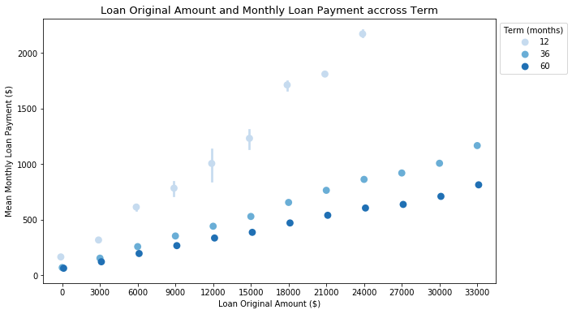

```python
# Create pointplot of Loan Original Amount and Monthly Loan Payment accross Term
plt.figure(figsize = [10, 6])
ax=sb.pointplot(data=df_reduced_vars,x='LoanAmount',y = 'MonthlyLoanPayment' ,hue='Term' ,palette='Blues',linestyles="",dodge=True)
ax.set_yticklabels([],minor=True)
x_y_t('Loan Original Amount ($)','Mean Monthly Loan Payment ($)','Loan Original Amount and Monthly Loan Payment accross Term')
plt.legend(bbox_to_anchor=(1,1),title='Term (months)',loc="upper left");
```

> It is shown by the dogded point plot that there is a clearly consistent pattern of loan original amount and term on monthly loan payment. Mean of monthly loan payment increases gradually as loan original amount is getting more considerable. The monthly payment amount appears to be proportionally greater for the length of 3 years compared to that amount for the length of 5 years.

> The larger error bars for term 12 at some loan amounts are due to there being few loans at this term level. There is no observation of loan being at term 12 for loan amounts greater than 25k. This makes sense because as demonstrated in the univariate exploration, there is only 1.5% of loans having term of 12 months.

> Lastly, we look at the interaction between Income range and Borrower APR accross Loan Status.

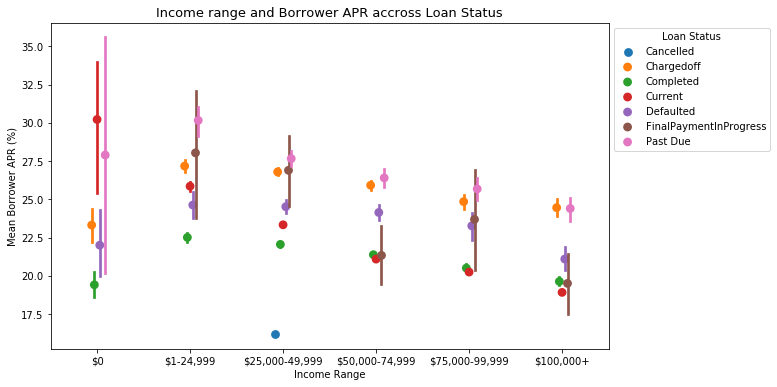

```python
# Create pointplot of Income range and Borrower APR accross Loan Status
plt.figure(figsize = [10, 6])
ax=sb.pointplot(data=df_reduced_vars,x='IncomeRange',y = 'BorrowerAPR_percent' ,hue='LoanStatus_grouped',linestyles="",dodge=True)
x_y_t('Income Range','Mean Borrower APR (%)','Income range and Borrower APR accross Loan Status')
plt.legend(bbox_to_anchor=(1,1),title='Loan Status',loc="upper left");
```

> The large error bars for income staying at 0 are due to there being few loans for this income range customer, which consists only 621 loans in this data set. There are also few loans being cancelled or being in their progesses of final payment.

### Some of the main relationships that are observed in this part of the investigation. Are there features that strengthened each other in terms of looking at the feature of interest?

> First of all, in the earlier bivariate section, the scatter plots suggests that bigger loan amount seems to get cheaper interest rates. But with multivariate exploration, we can see clearly that prosper rating scale appears to be the factor that affects both borrower APR and original loan amount. The reason why bigger loan amount receives smaller interest rates is because the customers who can get more considerate amounts of loan are the ones having high credit ratings, which seems to lead to cheaper borrowing rates.

> Secondly, the multivariate plot depicts a significant correlation between Borrower APR and loan original amount acrross monthly loan payment. High proportion of borrowers seem to take loans smaller than 10k,mostly between 3K and 5K and pay less than 200 monthly. The higher the loan original amount customers take, the bigger monthly payment they make but few customers borrow more than 30k and pay monthly more than 1k.

### Are there any interesting or surprising interactions between features?

> I looked at how loan original amount and monthly loan payment accross Term. The finding indicates that there is a clearly consistent pattern of loan original amount and term on monthly loan payment. Mean of monthly loan payment increases gradually as loan original amount is getting more considerable. The monthly payment amount appears to be proportionally greater for the length of 36 months compared to that amount for the length of 60 months.